# Regression

Parth Pansara

2025-03-30

```r
library(readr)
data = read_csv("final_cleaned_data.csv")
library(randomForest)
library(caret)       # for evaluation metrics
```

```r
library(ggplot2)
library(dplyr)
library(knitr)
```

```r
# Convert Time to Hour
data$Hour <- as.numeric(substr(data$Time, 1, 2))

# Create a new dataframe with required columns
df <- data %>%
  select(CO.GT., T, RH, Hour, PT08.S1.CO.) %>%
  na.omit()

#Rename columns for simplicity
colnames(df) <- c("CO", "Temperature", "Humidity", "Hour", "SensorCO")

#normalize T and RH
df$Temperature <- scale(df$Temperature)
df$Humidity <- scale(df$Humidity)
```

why do we normalize T and RH?

We normalize T and RH to put them on the same scale, ensuring fair contribution in models like Linear Regression. Without normalization, variables with larger ranges (like RH) can dominate the model. It improves interpretability, especially for comparing feature importance. While Random Forest doesn’t require normalization, it doesn’t hurt.

```r
# Evaluation function for model performance
eval_model <- function(actual, predicted) {
  data.frame(
    R2 = R2(predicted, actual),
    RMSE = RMSE(predicted, actual),
    MAE = MAE(predicted, actual)
  )
}
```

```r
#Train-Test Split
set.seed(123)
trainIndex <- createDataPartition(df$CO, p = 0.8, list = FALSE)
train <- df[trainIndex, ]
test <- df[-trainIndex, ]
```

why do we need train_test split?

We do a train-test split to evaluate how well our model performs on unseen data. The training set is used to build (fit) the model, while the test set simulates new data to assess prediction accuracy. This helps detect overfitting — when a model memorizes the training data but fails to generalize. Without splitting, we risk overly optimistic results. It’s essential for building reliable, real-world models.

```r
# --- Baseline Model (without SensorCO) ---
lm_base <- lm(CO ~ Temperature + Humidity + Hour, data = train)
summary(lm_base)
```

```
##
## Call:
## lm(formula = CO ~ Temperature + Humidity + Hour, data = train)
##
## Residuals:
##     Min      1Q  Median      3Q     Max
## -3.1744 -0.9072 -0.2956  0.5908  8.9343
##
## Coefficients:
##             Estimate Std. Error t value Pr(>|t|)
## (Intercept) 1.102427   0.029895  36.877   <2e-16 ***
## Temperature 0.027589   0.018174   1.518    0.129
## Humidity    0.204091   0.018575  10.987   <2e-16 ***
## Hour        0.083022   0.002245  36.983   <2e-16 ***
## ---
## Signif. codes:  0 '***' 0.001 '**' 0.01 '*' 0.05 '.' 0.1 ' ' 1
##
## Residual standard error: 1.288 on 7483 degrees of freedom
## Multiple R-squared:  0.1557, Adjusted R-squared:  0.1554
## F-statistic: 460.1 on 3 and 7483 DF,  p-value: < 2.2e-16
```

```r
lm_base_preds <- predict(lm_base, test)
lm_base_metrics <- eval_model(test$CO, lm_base_preds)
print(lm_base_metrics)
```

```
##          R2     RMSE       MAE
## 1 0.1529043 1.304128 0.9852365
```

```r
# --- Enhanced Model (with SensorCO) ---
lm_enh <- lm(CO ~ Temperature + Humidity + Hour + SensorCO, data = train)
summary(lm_enh)
```

```
##
## Call:
## lm(formula = CO ~ Temperature + Humidity + Hour + SensorCO, data = train)
##
## Residuals:
##     Min      1Q  Median      3Q     Max
## -4.4357 -0.3430 -0.0243  0.3175  5.4265
##
## Coefficients:
##               Estimate Std. Error t value Pr(>|t|)
## (Intercept) -3.531e+00  4.411e-02 -80.040  < 2e-16 ***
## Temperature -7.563e-02  1.096e-02  -6.900 5.63e-12 ***
## Humidity    -4.223e-02  1.137e-02  -3.715 0.000205 ***
## Hour         2.632e-02  1.437e-03  18.319  < 2e-16 ***
## SensorCO     4.739e-03  4.121e-05 115.005  < 2e-16 ***
## ---
## Signif. codes:  0 '***' 0.001 '**' 0.01 '*' 0.05 '.' 0.1 ' ' 1
##
## Residual standard error: 0.7745 on 7482 degrees of freedom
## Multiple R-squared:  0.695,  Adjusted R-squared:  0.6948
## F-statistic:  4261 on 4 and 7482 DF,  p-value: < 2.2e-16
```

```r
lm_enh_preds <- predict(lm_enh, test)
lm_enh_metrics <- eval_model(test$CO, lm_enh_preds)
print(lm_enh_metrics)
```

```
##          R2      RMSE       MAE
## 1 0.7226896 0.7475835 0.5066121
```

Model with SensorCO: - Explains ~69.5% of the variation in CO(GT) — a huge improvement. - Has a much lower residual error (0.77 vs 1.29). - SensorCO has a very strong effect (t-value 115!). - All variables are highly significant (p < 0.001).

Model without SensorCO: - Only explains ~15.6% of variation. - Humidity and Hour help, but not nearly enough. - Temperature wasn’t even statistically significant (p = 0.129).

We first built a linear regression model using only environmental variables (Temperature, Humidity, and Hour). This baseline model achieved an $R^2$ of 0.156, indicating a weak fit. After adding SensorCO — a sensor response variable — the $R^2$ jumped to 0.695, and residual error decreased substantially. This demonstrates that sensor data significantly improves the model’s ability to predict CO(GT), confirming a strong nonlinear or sensor-driven component in CO prediction.

```r
# Random Forest Baseline (without SensorCO)
rf_base <- randomForest(CO ~ Temperature + Humidity + Hour, data = train)
rf_base_preds <- predict(rf_base, test)
rf_base_metrics <- eval_model(test$CO, rf_base_preds)
print(rf_base_metrics)
```

```
##         R2     RMSE       MAE
## 1 0.411828 1.086694 0.7646154
```

```r
# Random Forest Enhanced (with SensorCO)
rf_enh <- randomForest(CO ~ Temperature + Humidity + Hour + SensorCO, data = train)
rf_enh_preds <- predict(rf_enh, test)
rf_enh_metrics <- eval_model(test$CO, rf_enh_preds)
print(rf_enh_metrics)
```

```
##          R2     RMSE      MAE
## 1 0.8291442 0.594551 0.407363
```

```r
model_results <- data.frame(
  Model = c(
    "Linear Regression (No SensorCO)",
    "Linear Regression (With SensorCO)",
    "Random Forest (No SensorCO)",
    "Random Forest (With SensorCO)"
  ),
  R2 = c(0.153, 0.723, 0.412, 0.829),
  RMSE = c(1.304, 0.748, 1.087, 0.595),
  MAE = c(0.985, 0.507, 0.765, 0.407)
)

# Display as a formatted table
kable(model_results, caption = "Model Comparison: CO(GT) Prediction Performance")
```

Model Comparison: CO(GT) Prediction Performance

| Model | R2 | RMSE | MAE |
| --- | --- | --- | --- |
| Linear Regression (No SensorCO) | 0.153 | 1.304 | 0.985 |
| Linear Regression (With SensorCO) | 0.723 | 0.748 | 0.507 |
| Random Forest (No SensorCO) | 0.412 | 1.087 | 0.765 |
| Random Forest (With SensorCO) | 0.829 | 0.595 | 0.407 |

- SensorCO drastically improves accuracy in both models.
- Random Forest outperforms Linear Regression in both baseline and enhanced versions.
- Best model: Random Forest with SensorCO ($R^2$ = 0.83, RMSE = 0.595, MAE = 0.407)

We compared linear and nonlinear regression models to predict carbon monoxide levels (CO(GT)) using environmental variables and sensor data. In the baseline models (without sensor input), linear regression achieved an $R^2$ of 0.153, while Random Forest reached 0.412. After including the sensor variable PT08.S1.CO., performance improved significantly: $R^2$ increased to 0.723 for the linear model and to 0.829 for Random Forest. This demonstrates that sensor input plays a vital role in accurately predicting CO levels, and that nonlinear models like Random Forest provide a superior fit for the data.

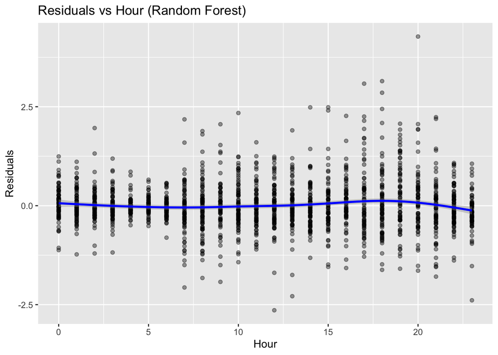

```r
# Residuals from best model (Random Forest with SensorCO)
residuals_rf <- test$CO - rf_enh_preds

ggplot(data.frame(Hour = test$Hour, Residuals = residuals_rf), aes(x = Hour, y = Residuals)) +
  geom_point(alpha = 0.4) +
  geom_smooth(color = "blue") +
  ggtitle("Residuals vs Hour (Random Forest)") +
  xlab("Hour") + ylab("Residuals")
```

This plot shows the residuals (prediction errors) across different hours of the day. The residuals are generally centered around zero with no clear pattern, suggesting that the Random Forest model handles time-of-day variation well and does not exhibit time-based bias. The smooth trend line is fairly flat, which supports the assumption of well-distributed errors over time.

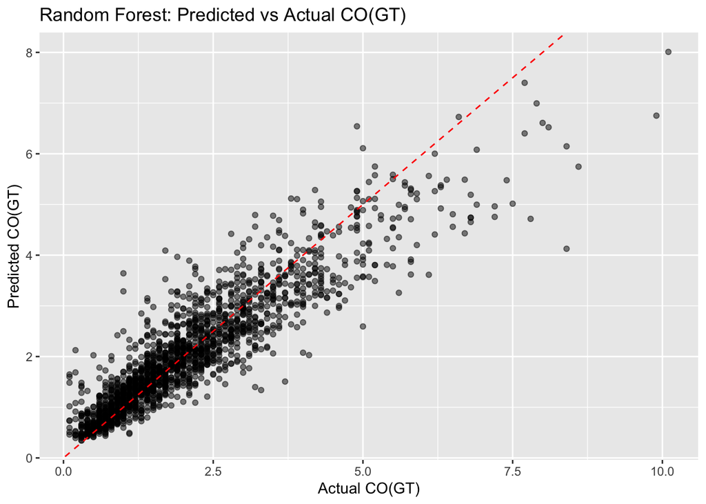

```r
ggplot(data.frame(Actual = test$CO, Predicted = rf_enh_preds), aes(x = Actual, y = Predicted)) +
  geom_point(alpha = 0.5) +
  geom_abline(slope = 1, intercept = 0, linetype = "dashed", color = "red") +
  ggtitle("Random Forest: Predicted vs Actual CO(GT)") +
  xlab("Actual CO(GT)") + ylab("Predicted CO(GT)")
```

This scatter plot compares the actual vs. predicted CO(GT) values. The data points are closely clustered around the diagonal reference line (dashed red), especially in the lower range where most values lie. This indicates a strong correlation and accurate predictions from the Random Forest model. Slight underestimation is visible at higher CO levels, likely due to fewer high-concentration cases in the training data.

```r
# Create a new dataframe without CO.GT. (target) and any irrelevant vars (like Date/Time)
df_full <- data %>%
  select(-Date, -Time) %>%
  rename(CO = CO.GT.)

set.seed(123)
trainIndex <- createDataPartition(df_full$CO, p = 0.8, list = FALSE)
train <- df_full[trainIndex, ]
test <- df_full[-trainIndex, ]
```

```r
lm_all <- lm(CO ~ ., data = train)
summary(lm_all)  # Optional: See which predictors are significant
```

```
##
## Call:
## lm(formula = CO ~ ., data = train)
##
## Residuals:
##     Min      1Q  Median      3Q     Max
## -4.7013 -0.1812  0.0063  0.1986  4.0481
##
## Coefficients:
##                 Estimate Std. Error t value Pr(>|t|)
## (Intercept)   -1.529e+00  1.054e-01 -14.509  < 2e-16 ***
## PT08.S1.CO.    1.185e-03  7.255e-05  16.334  < 2e-16 ***
## C6H6.GT.       7.905e-02  1.326e-03  59.596  < 2e-16 ***
## PT08.S2.NMHC. -3.518e-04  1.077e-04  -3.267  0.00109 **
## NOx.GT.        2.347e-03  6.368e-05  36.858  < 2e-16 ***
## PT08.S3.NOx.   2.605e-04  4.730e-05   5.507 3.77e-08 ***
## NO2.GT.        2.356e-03  2.558e-04   9.209  < 2e-16 ***
## PT08.S4.NO2.   1.077e-03  5.702e-05  18.888  < 2e-16 ***
## PT08.S5.O3.   -2.340e-04  4.216e-05  -5.551 2.94e-08 ***
## T             -1.861e-02  2.308e-03  -8.064 8.53e-16 ***
## RH            -5.157e-03  9.029e-04  -5.711 1.17e-08 ***
## AH            -1.034e-01  4.504e-02  -2.296  0.02172 *
## Hour           1.414e-02  9.674e-04  14.619  < 2e-16 ***
## ---
## Signif. codes:  0 '***' 0.001 '**' 0.01 '*' 0.05 '.' 0.1 ' ' 1
##
## Residual standard error: 0.4822 on 7474 degrees of freedom
## Multiple R-squared:  0.8819, Adjusted R-squared:  0.8817
## F-statistic:  4650 on 12 and 7474 DF,  p-value: < 2.2e-16
```

```r
# Predict and evaluate
lm_all_preds <- predict(lm_all, test)
lm_all_metrics <- eval_model(test$CO, lm_all_preds)

print("Full Linear Model (All Variables):")
```

```
## [1] "Full Linear Model (All Variables):"
```